# K-Means Clustering

Josh Olsen

9/20/2021

## The Dataset

Each Variable is listed below:  
**mpg** = Miles/(US) gallon  
**cyl** = Number of cylinders  
**disp** = Displacement (cu.in.)  
**hp** = Gross horsepower  
**drat** = Rear axle ratio  
**wt** = Weight (1000 lbs)  
**qsec** = 1/4 mile time  
**vs** = Engine (0 = V-shaped, 1 = straight)  
**am** = Transmission (0 = automatic, 1 = manual)  
**gear** = Number of forward gears  
**carb** = Number of carburetors

|  | mpg | cyl | disp | hp | drat | wt | qsec | vs | am | gear | carb |
| --- | --- | --- | --- | --- | --- | --- | --- | --- | --- | --- | --- |
| Mazda RX4 | 21.0 | 6 | 160.0 | 110 | 3.90 | 2.620 | 16.46 | 0 | 1 | 4 | 4 |
| Mazda RX4 Wag | 21.0 | 6 | 160.0 | 110 | 3.90 | 2.875 | 17.02 | 0 | 1 | 4 | 4 |
| Datsun 710 | 22.8 | 4 | 108.0 | 93 | 3.85 | 2.320 | 18.61 | 1 | 1 | 4 | 1 |
| Hornet 4 Drive | 21.4 | 6 | 258.0 | 110 | 3.08 | 3.215 | 19.44 | 1 | 0 | 3 | 1 |
| Hornet Sportabout | 18.7 | 8 | 360.0 | 175 | 3.15 | 3.440 | 17.02 | 0 | 0 | 3 | 2 |
| Valiant | 18.1 | 6 | 225.0 | 105 | 2.76 | 3.460 | 20.22 | 1 | 0 | 3 | 1 |
| Duster 360 | 14.3 | 8 | 360.0 | 245 | 3.21 | 3.570 | 15.84 | 0 | 0 | 3 | 4 |
| Merc 240D | 24.4 | 4 | 146.7 | 62 | 3.69 | 3.190 | 20.00 | 1 | 0 | 4 | 2 |
| Merc 230 | 22.8 | 4 | 140.8 | 95 | 3.92 | 3.150 | 22.90 | 1 | 0 | 4 | 2 |
| Merc 280 | 19.2 | 6 | 167.6 | 123 | 3.92 | 3.440 | 18.30 | 1 | 0 | 4 | 4 |

[output cut: 22 more lines]

## Correlation Plot

From looking at the correlation plot, we can visually see the if each pair of variables are linearly related. The blue circles represent a positive correlation while the red circles represent a negative correlation. The darker the color, the stronger the correlation is between the variables.

The Displacement (disp) variable has a very strong positive correlation with Gross Horsepower (hp)

The Miles Per Gallon (mpg) variable has a very strong negative correlation with Weight (wt).

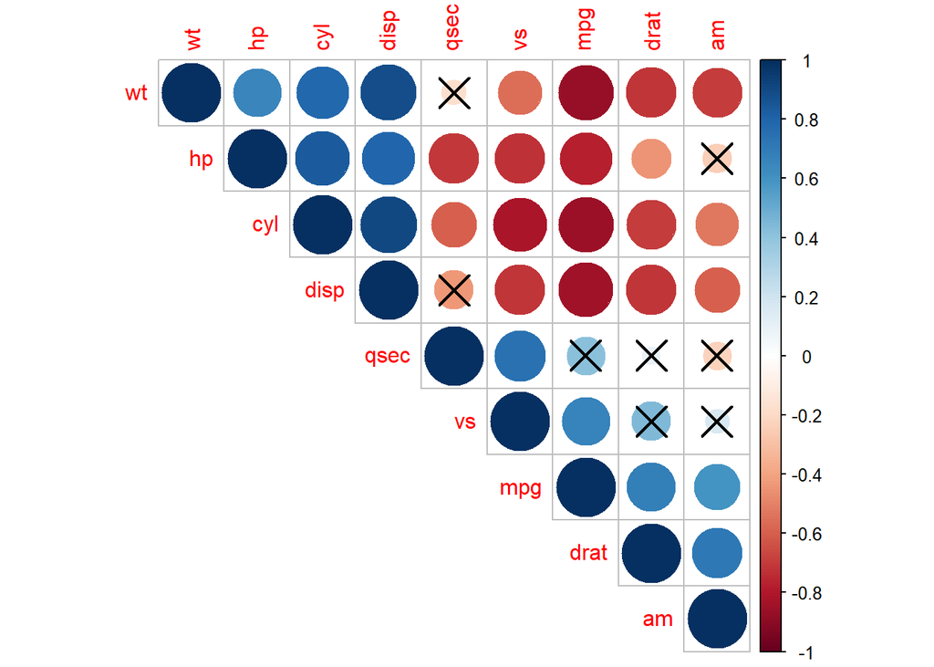

```r
library(corrplot)


corrplot(res2$r, type="upper", order="hclust",
         p.mat = res2$P, sig.level = 0.01)
```

## Plotting the Negative and Poistive Correlation Example:

Below are two plots that display the positive and negative examples mentioned above.

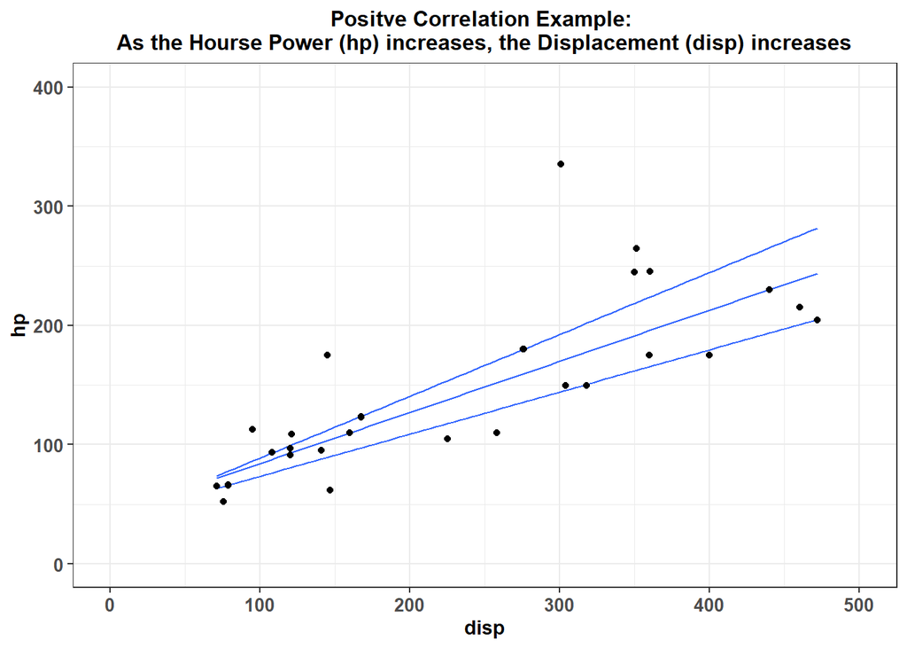

```r
library(ggplot2)

theme <-  theme_bw() +
  theme(axis.text.x = element_text(face="bold", size=10),
        axis.text.y = element_text(face="bold", size=10),
        plot.title = element_text(face="bold", size=12, hjust = 0.5),
        axis.title.x = element_text(face="bold", size=11),
        axis.title.y = element_text(face="bold", size=11),
        plot.caption = element_text(size=7))


v2 <- ggplot(data = mtcars_df, mapping = aes(x = disp , y = hp))
  v2 +
  geom_quantile() +
  geom_jitter() +
  theme + ggtitle("Positve Correlation Example:
As the Hourse Power (hp) increases, the Displacement (disp) increases") +
  scale_y_continuous(limits = c(0, 400)) +
  scale_x_continuous(limits = c(0, 500))
```

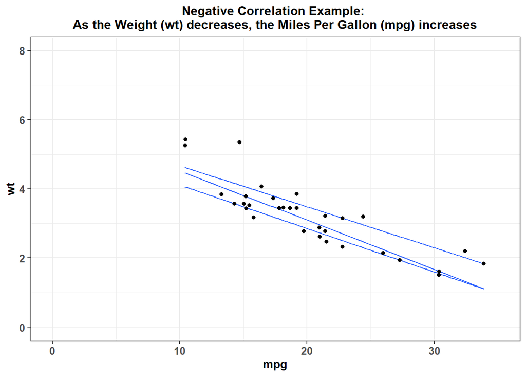

```r
  v1 <- ggplot(data = mtcars_df, mapping = aes(x = mpg , y = wt))
  v1 +
  geom_quantile() +
  geom_jitter() +
  theme + ggtitle("Negative Correlation Example:
As the Weight (wt) decreases, the Miles Per Gallon (mpg) increases") +
  scale_y_continuous(limits = c(0, 8)) +
  scale_x_continuous(limits = c(0, 35))
```

## Finding Number of Optimal Clusters

NbClust package is used for determining the number of clusters and proposes to user the best clustering scheme from the different results obtained by varying all combinations of number of clusters, distance measures, and clustering methods.

The optimal number of clusters is 3

```r
library(NbClust)
NbClust(mtcars_df, method = 'complete', index = 'hartigan')$Best.nc
```

```
## Number_clusters     Value_Index
##          3.0000         34.1696
```

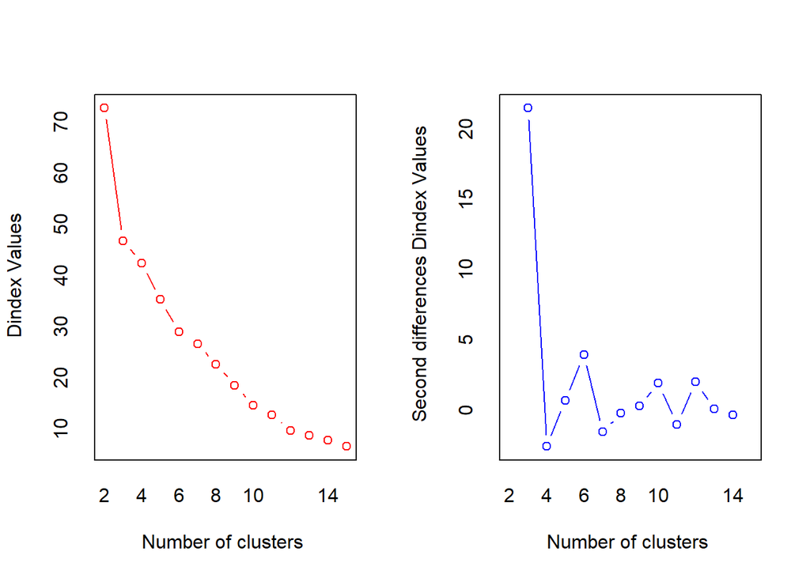

```
## *** : The D index is a graphical method of determining the number of clusters.
##                 In the plot of D index, we seek a significant knee (the significant peak in Dindex
##                 second differences plot) that corresponds to a significant increase of the value of
##                 the measure.
##
```

```
## $All.index
##       2       3       4       5       6       7       8       9      10      11
## 72.7057 46.7853 42.3456 35.3250 28.9805 26.5845 22.6468 18.4954 14.6324 12.6791
##      12      13      14      15
##  9.6989  8.7226  7.8260  6.5758
```

```r
NbClust(mtcars_df, method = 'complete', index = 'dindex')
```

## Plotting the Three Clusters

First step is to take calculate the distance matrix computed by using the specified distance measure to compute the distances between the rows of a data.

Second step is to perform the hierarchical cluster analysis that uses a set of dissimilarities for the n objects being clustered. In this case, 32 objects.

Initially, each object is assigned to its own cluster and then the algorithm proceeds iteratively, at each stage joining the two most similar clusters, continuing until there is just a single cluster.

At each stage distances between clusters are recomputed by the Lance–Williams dissimilarity update formula according to the particular clustering method being used.

Below is a cluster dendrogram that groups each car into three clusters based on the hierarchical cluster analysis.

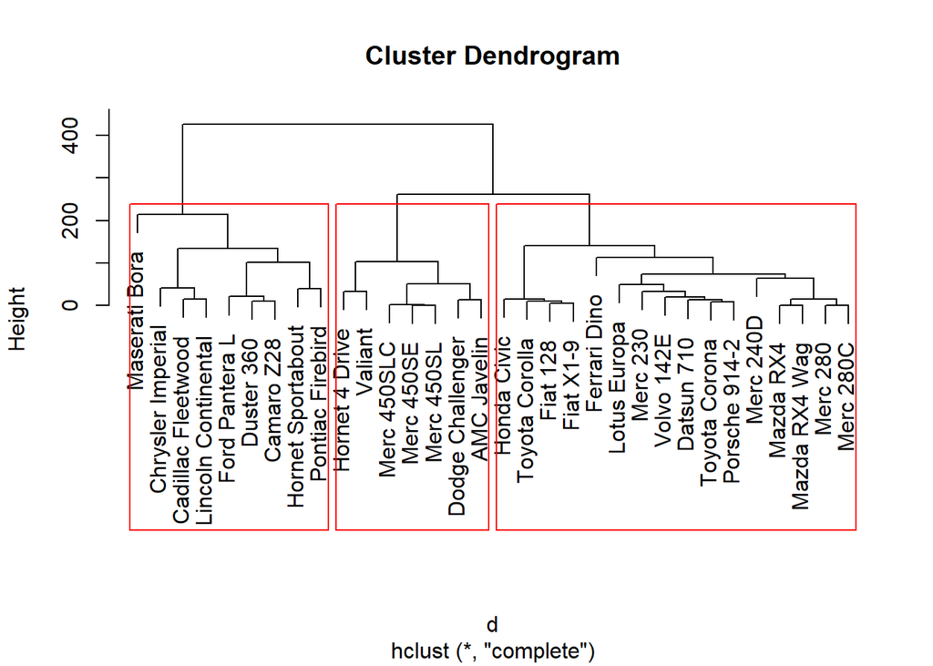

```r
d <- dist(mtcars_df)
h <- hclust(d)

plot(h)
rect.hclust(h, k = 3, border = 'red')
```

## K-Means Model Visual

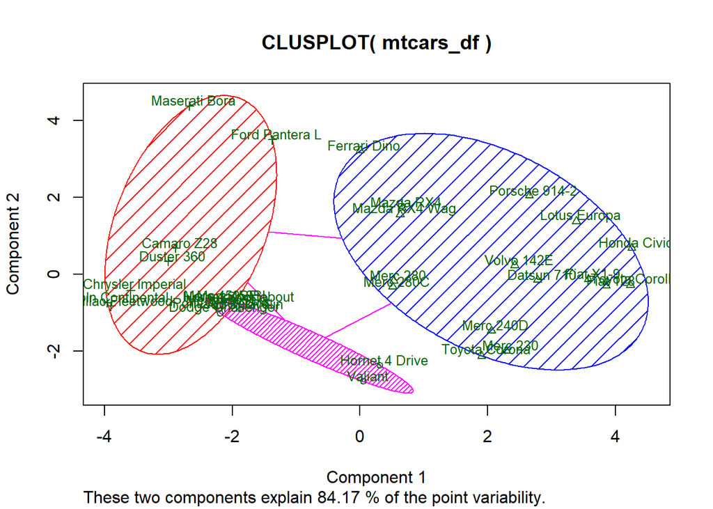

```r
library(cluster)
v3 <- clusplot(mtcars_df, k$cluster, color = TRUE, shade = TRUE, labels = 3, cex = 0.8)
```